# SRM Chapter 2.1

theBudgetActuary

# **What We Will Cover:**

#### Chapter1: Understanding the Data (easy)

#### **Chapter2:** **KNN and Simple Linear Regression (medium)**

#### Chapter3: Multiple Linear Regression and Variants (medium)

#### Chapter4: Time Series Data (medium)

#### Chapter5: Tree Based Algorithms (easy)

#### Chapter6: Unsupervised Models (medium-hard)

#### Chapter7: Non-Linear Models (very hard)

#### Chapter8: Miscellaneous

# **SLR**

#### *Supervised/Unsupervised:* **Supervised**

#### *Type of Model:* **Regression**

#### *Parametric/Non-Parametric:* **Parametric**

#### *Tuning Parameters:* **None**

#### **Model Equation:** $\hat{y}=\hat{\beta}_{0}+\hat{\beta}_{1}x+\epsilon$

- $\beta_{0}$: Y-Intercept term.
- $\beta_{1}$: Slope term.
- $\epsilon$: Covers everything missed in the model such as other variables that cause variation in y, measurement error, or if the relationship between x and y is not truly linear.

($James, ISLR, p.63$)

## **SLR Plot:**

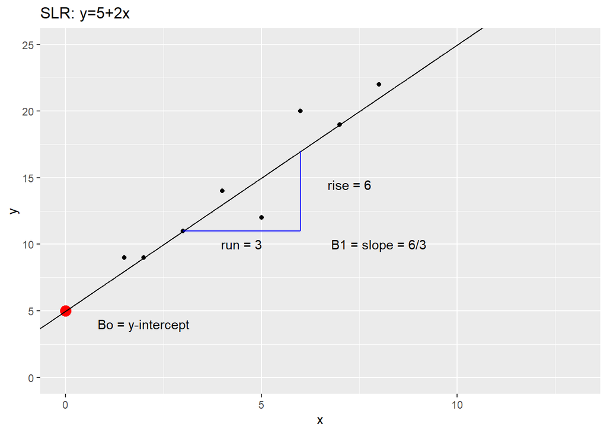

## **How Does SLR Work?**

Simple linear regression assumes an approximately linear relationship between the predictor variable x, and the dependent variable y. The SLR line is fit by minimizing the **sum of squared residuals**. This is done by adjusting its two parameters, $\beta_{0}$ and $\beta_{1}$.  
($James, ISLR, p.59-61$)

These two estimated parameters are known as the least squares coefficient estimates. They are unbiased estimates because if we take a large number of samples and fit a SLR model to each of them, we would expect slightly different parameter estimates for $\beta_{0}$ and $\beta_{1}$. But, if we average these parameter estimates out for each of the SLR models, the estimates would approach the true population parameter values.

**Residual-** Difference between the observed value and the predicted value. When we minimize the SSE, the sum of residuals will be equal to 0.

> residual: $y_{i}-\hat{y}$ = (observed - predicted)

> $\hat{y}=\hat{\beta}_{0}+\hat{\beta}_{1}x+\epsilon$

When Minimizing SSE:

> $\sum_{i=1}^{n}e_{i}$ = 0

**MSE-** The sum of squared residuals divided by the degrees of freedom.

> MSE: $\frac{SSE}{n-p-1}$

**SSE-** Sum of Squares Errors is the amount of unexplained variability from a model. Also known as the Sum of Squares Residuals or Residual Sum of Squares (RSS). It is what we try to minimize when choosing our best fit simple linear regression line.

> SSE: $\sum_{i=1}^{n}(y_{i}-\hat{y}_{i})^2$

**SSR-** Sum of Squares Regression is the amount of explained variability from a model.

> SSR: $\sum_{i=1}^{n}(\hat{y}_{i}-\bar{y})^2$

For SLR, SSR can also be found as:

> SSR: $\beta_{1}^{2}\sum_{i=1}^{n}(x_{i}-\bar{x})^{2}$

**SST-** Sum of Squares Total (or Total Sum of Squares) is the total variability that exists in the dependent variable.

> SST: $\sum_{i=1}^{n}(y_{i}-\bar{y})^2$

> $\underset{total}{SST}=\underset{explained}{SSR}+\underset{unexplained}{SSE}$

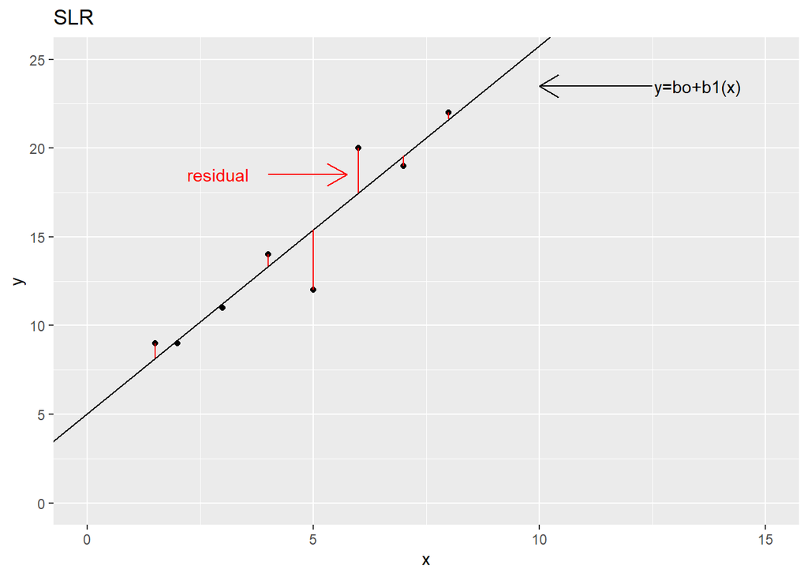

# **How to Interpret SLR?**

> $\hat{y} = \beta_{0}+\beta_{1}(x)$

How we can interpret SLR is that by holding all else constant, with an one unit increase in x we can expect a $\beta_{1}$ unit increase in y.

For example, if we are given the simple linear regression equation of: $weight_{plds} = 8 + 5(age_{years})$, it can be interpreted that with a one year increase in age, we can expect a 5 pound increase in a person. The intercept, or $\beta_{0}$, can be somewhat arbitrary. Such as in this example it is saying that if a person is 0 years old (not born yet) we would guess a weight of 8.

With this equation we can make a prediction of an individuals weight using their age. If an individual is 10 years old, our prediction for their weight would be weight=8+5(**10**) = 58 pounds.

# **How Do We Estimate $\beta_{0}$ and $\beta_{1}$**?

In SLR, $\beta_{0}$ and $\beta_{1}$ can be solved algebraically:

> $\beta_{1}$: $\frac{Cov_{x,y}}{Var_{x}}$ = $\frac{\sum_{i=1}^{n}(x_{i}-\bar{x})(y_{i}-\bar{y})}{\sum_{i=1}^{n}(x_{i}-\bar{x})^2}$

> $\beta_{0}$: $\bar{y}=\hat{\beta}_{0}+\hat{\beta}_{1}\bar{x}$

**Parameter Values Can Also Be Solved On Calculator:**

1. stat -> fill L1 with x’s, fill L2 with y’s
2. $2_{nd}$ -> stat -> 2-Var Stats -> enter
3. a = $\beta_{1}$, b = $\beta_{0}$

# **How Do We Know If Our Model is Any Good?**

## **Residual Standard Error (RSE)-**

Can be interpreted as the average amount that the response will deviate from the true regression line. For instance, if the predictor is the height in inches, and the RSE is 2.5, then the actual height will deviate from the true regression line by on average 2.5 inches. $James, ISLR, p.69$

> RSE = $\sqrt{MSE}$ = $\sqrt{\frac{SSE}{n-p-1}}$

## $\textbf R^{2}$-

Represents the proportion of total variability explained by the model.

> $R^{2}$= $1-\frac{SSE}{SST}$ = $\frac{SSR}{SST}$

For SLR, $R^{2}$ can also be found as:

> $R^{2}$ = $cor_{x,y}^{2}$

**Sources:**

James, G., Witten, D., Hastie, T., & Tibshirani, R. (2021). An Introduction to Statistical Leaning: With Applications in R. Springer.

Zaiontz, C. (2020). Confidence and prediction intervals for forecasted values. Retrieved 1 July 2022, from https://www.real-statistics.com/regression/confidence-and-prediction-intervals/